# Spectral Unmixing of Antarctic Arctic Snow Grain Size Distribution: A Data-Driven Perspective

*Facu Sapienza, Shane Grigsby, Whyjay Zheng, Jonathan Taylor, Tasha Snow, Fernando Pérez, Matt Siegfried*

Surface snow properties provide useful information about climate processes, specially in large extends like Antarctica and Greenland. For example, large grains of snow can indicate a recent snowfall, while periods without new deposition of snow are associated with more compacted firm.

In-situ measurements provide accurate local estimates of grain size but are usually sparse and difficult to perform. The goal of this project is to provide snow grain size estimates based on optical remote sensing data over large spatial extents and for long periods of time.

```python
%pylab inline
```

```python
import numpy as np
import xarray as xr
import pandas as pd
import pickle
import matplotlib.pyplot as plt
from scipy.optimize import minimize, Bounds, LinearConstraint
from scipy.interpolate import griddata
from scipy.signal import argrelextrema
import regreg.api as rr
from regreg.affine.fused_lasso import trend_filter
from regreg.atoms.simplex import simplex_constraint

plt.rcParams['figure.figsize'] = (15,10)
plt.rcParams['font.size'] = 34
plt.rcParams['axes.titlesize'] = 34
```

## 1. Endmember Library

For shadow, we use `np.array([699.523560, 481.529114, 327.151794, 193.666256, 60.180717, 0.000000, 0.000000])`. They are from the the first row with a grain size of 0 micron except for the fourth number. The effect of dust is accounted by the contribition of particles of ice of size between 10 and 20 nm.

```python
speclib = pd.read_csv('./endmembers/speclib.z30.txt', sep=' ', index_col=False, names=['b3','b4','b1','b2','b5','b6','b7'])
surftype = pd.read_csv('./endmembers/emtype.txt', sep=' ', index_col=False, names = ['cat'])
grainsize = pd.read_csv('./endmembers/grainsize.txt', sep=' ', index_col=False, names=['grainsize'])

# Grabbing just snow
speclib = speclib[(surftype == 0).values]
grainsize = grainsize[(surftype == 0).values]

# Setting index to grainsize
speclib.index = grainsize.grainsize.values

# Picking just ice responses
speclib_grainsize = speclib.iloc[:-2,:]
grainsizes = speclib_grainsize.index

# Adding shadow component
spec_shadow = np.array([699.523560, 481.529114, 327.151794, 193.666256, 60.180717, 0., 0.])

X0 = speclib_grainsize.values.T
```

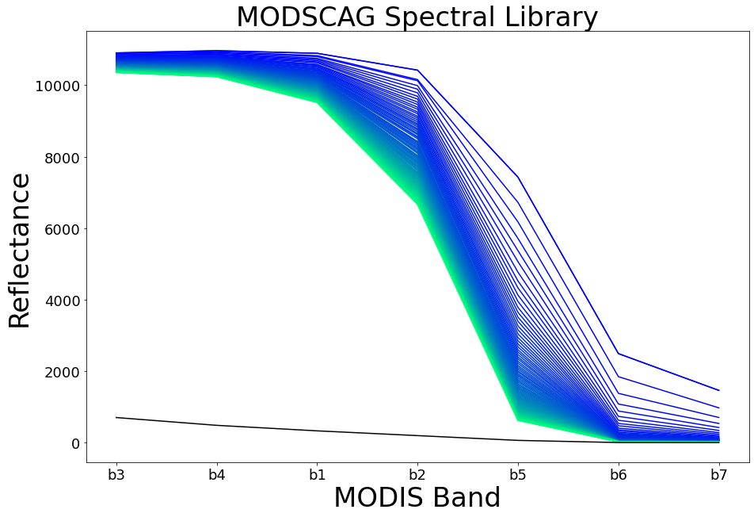

```python
# Bands names
data_x = ['b3','b4','b1','b2','b5','b6','b7']

speclib_grainsize.T.plot(legend=False, colormap="winter", fontsize=18, style="-")
plt.plot(data_x, spec_shadow, "black", label="Shadow")

plt.title("MODSCAG Spectral Library")
plt.xlabel("MODIS Band")
plt.ylabel("Reflectance");

plt.savefig("MODSCAG.png", dpi=300, format="png", transparent=True)
```

## 2. MODIS Data

```python
dsT = xr.open_zarr("s3://geostacks/summitValTerra.zarr")
dsT = dsT.isel(x=slice(95,102), y=slice(95,102))
dsT = dsT.dropna(dim="time", how="any")

dsT
```

```
<xarray.Dataset>
Dimensions:   (time: 301, x: 7, y: 7, nm: 7)
Coordinates:
    easting   (x) int64 dask.array<chunksize=(7,), meta=np.ndarray>
  * nm        (nm) int64 469 555 645 859 1240 1639 2130
    northing  (y) int64 dask.array<chunksize=(7,), meta=np.ndarray>
  * time      (time) datetime64[ns] 2011-05-01T01:00:00 ... 2011-06-20T23:50:00
Dimensions without coordinates: x, y
Data variables:
    clouds    (time, x, y) float64 dask.array<chunksize=(39, 5, 5), meta=np.ndarray>
    lats      (time, x, y) float64 dask.array<chunksize=(39, 5, 5), meta=np.ndarray>
    lons      (time, x, y) float64 dask.array<chunksize=(39, 5, 5), meta=np.ndarray>
    snow      (time, x, y) float64 dask.array<chunksize=(39, 5, 5), meta=np.ndarray>
    spectra   (time, nm, x, y) float64 dask.array<chunksize=(39, 2, 5, 5), meta=np.ndarray>
Attributes:
    description:  Spectra Data. Tera
```

We can visualize one of the characteristical reflactances of a MODIS image for the selected area.

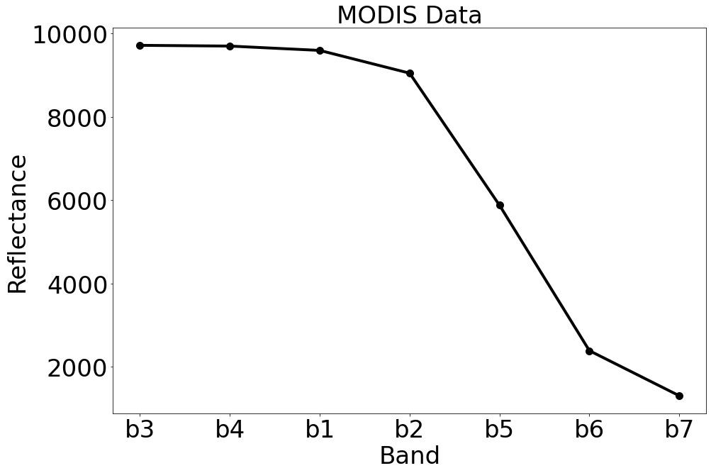

```python
plt.plot(data_x, dsT.spectra[1,:,0,0].values, 'o-', ms=10, lw=4, color='black')

plt.title("MODIS Data")
plt.xlabel("Band")
plt.ylabel("Reflectance");

plt.savefig("MODIS_ref.png", dpi=300, format="png", transparent=True)
```

## 3. Summit Climate Data

In order to compare our estimates for grain sizes with climate, we use the cloud and weather information retrieved in-situ in the Summit station.

```python
summit_file = "./Summit_data.pkl"
Summit_data = pd.read_pickle(summit_file)
Summit_data
```

|  | index | date | detection_status_id | detection_status |
| --- | --- | --- | --- | --- |
| 0 | 0 | 2011-05-19 00:00:06.999998400 | 4 | Obscured |
| 1 | 1 | 2011-05-19 00:00:21.999999600 | 5 | Unknown |
| 2 | 2 | 2011-05-19 00:00:37.000000800 | 5 | Unknown |
| 3 | 3 | 2011-05-19 00:00:51.999998400 | 5 | Unknown |
| 4 | 4 | 2011-05-19 00:01:06.999999600 | 5 | Unknown |
| ... | ... | ... | ... | ... |
| 337319 | 5762 | 2011-06-07 23:58:53.000000400 | 0 | Clr |
| 337320 | 5763 | 2011-06-07 23:59:08.000001600 | 0 | Clr |
| 337321 | 5764 | 2011-06-07 23:59:22.999999200 | 0 | Clr |
| 337322 | 5765 | 2011-06-07 23:59:38.000000400 | 0 | Clr |
| 337323 | 5766 | 2011-06-07 23:59:53.000001600 | 0 | Clr |

337324 rows × 4 columns

```python
Summit_weather = pd.read_pickle("./Summit_weather.pkl")
Summit_weather
```

|  | index | DATE | TIME | Wind_Speed | Wind_Direction | VISIBILITY | PRESENT | SKY CONDITION | TEMP | STATION | CLOUD | REMARKS | OBS | time |
| --- | --- | --- | --- | --- | --- | --- | --- | --- | --- | --- | --- | --- | --- | --- |
| 0 | 0 | 2011-05-01 | 0 | 5.7 | 196.0 | NaN | NaN | NaN | -36.0 | 674.3 | NaN | NaN | NaN | 2011-05-01 00:00:00 |
| 1 | 1 | 2011-05-01 | 1200 | 2.3 | 192.0 | 9999.0 | IC | FEW100 | -32.2 | 674.2 | Cirrostratus | NaN | mm | 2011-05-01 12:00:00 |
| 2 | 2 | 2011-05-01 | 1800 | 1.3 | 206.0 | 9999.0 | NaN | SKC | -28.2 | 674.5 | NaN | NaN | mm | 2011-05-01 18:00:00 |
| 3 | 3 | 2011-05-02 | 0 | 1.5 | 232.0 | 9999.0 | NaN | SKC | -39.2 | 675.3 | NaN | NaN | lr | 2011-05-02 00:00:00 |
| 4 | 4 | 2011-05-02 | 1200 | 5.6 | 247.0 | 9999.0 | NaN | FEW100 | -32.4 | 677.9 | Cirrostratus | NaN | mm/lr | 2011-05-02 12:00:00 |
| ... | ... | ... | ... | ... | ... | ... | ... | ... | ... | ... | ... | ... | ... | ... |
| 178 | 85 | 2011-06-29 | 1200 | 3.7 | 52.0 | 9999.0 | NaN | FEW100 | -13.4 | 684.8 | Cirrostratus | NaN | mm | 2011-06-29 12:00:00 |
| 179 | 86 | 2011-06-29 | 1800 | 4.9 | 87.0 | 9999.0 | SN | BKN010 | -11.0 | 684.7 | Altocumulus | NaN | lr | 2011-06-29 18:00:00 |
| 180 | 87 | 2011-06-30 | 0 | 5.5 | 53.0 | 9999.0 | NaN | FEW015 | -19.2 | 684.6 | Altocumulus | NaN | mm | 2011-06-30 00:00:00 |
| 181 | 88 | 2011-06-30 | 1200 | 4.2 | 30.0 | 9999.0 | NaN | SCT015 | -11.6 | 684.4 | Altocumulus | NaN | mm | 2011-06-30 12:00:00 |
| 182 | 89 | 2011-06-30 | 1800 | 7.2 | 32.0 | 9999.0 | SN | BKN015 | -9.9 | 684.3 | Altocumulus | NaN | lr | 2011-06-30 18:00:00 |

183 rows × 14 columns

## 4. Statistical Model

Let's denote by $b = 1, 2, \ldots, B = 7$ the different spectral bands. Our data consists on retrievals of MODIS data $Y^{(d)} \in \mathbb R^B$, where the superscript $d$ stands for the spatial (and temporal) location of each pixel (for example, we could have $d = (i,j)$, with $i$ and $j$ the horizontal and vertical indices in the MODIS grid).

We also have templates of spectral response $X^k \in \mathbb R^B$ associated to different grain sizes and shadow, which are labeled by $k = 1, 2, \ldots, K$, with $K$ the total number of endmembers. Let's define $X \in \mathbb R^{B \times K}$ the matrix of spectral responses, where each column corresponds to a response of a given grain size of snow or some other feature.

**Constraints**

In this kind of situations, two constraints are impossed on the vector of coefficients: non-negativity ($0 \leq \theta_i^{(d)}$) and the sum of the abundances must be equal to one ($\sum_i \theta_i^{(d)} = 1$) (Section 4.6.1 in [Hyperspectral Image Processing Techniques](https://www.sciencedirect.com/science/article/pii/B9780123747532100048?via%3Dihub))

**Regularization**

We continue to use the second-order Tikhonov regularization for grain size end members, assuming the grain size in a single pixel follows a smooth distribution. That is,

$$ \theta = (\beta_{1}, \beta_{2}, \ldots, \beta_{G}, \gamma) $$

where $\beta$ is the mixing ratio of a grain size, and $\gamma$ is the spectral contribution of shadow. The subscript of $\beta$ denotes the mixing ratio for a particular grain size, and in this notebook there are $G = K - 1$ grain size picks. To the loss function to be optimized (next section) we are going to add the regularization term
$$ \lambda \sum_{i=2}^{G-1} \left( \beta_{i-1} - 2\beta_i + \beta_{i+1} \right)^2, $$ where $\lambda$ is the regularization coefficient to be determined yet.

**Lost Function**

The goal is to find $\theta$ that minimizes the Huber loss function with splines regularization given by

$$ \| Y - X \theta - \eta \|_2^2 + \lambda \sum_{i=2}^{G-1} \left( \beta_{i-1} - 2\beta_i + \beta_{i+1} \right)^2 + \sum_{b=1}^B \nu_b | \eta_b |, $$

where $\eta \in \mathbb R^B$ is a new vector to be estimated and represents the correction we need to add to predict the correct response. This could be interpretated as a new endmember component we need to add to the library on order to obtain a correct fit. In principle, we $\eta$ could have both positive and negative entries. Just as $\lambda$, $\nu$ is a regularization parameter to be dermined.

For a fixed value of $\theta$, the value of $\eta$ that minimizes the loss functions is given by the soft-thresholding operation

$$ \eta_i = \text{sg}(R_i) \, \text{max} \left( 0, |R_i| - \nu_i / 2 \right), $$

with $R = Y - X \theta$ the residual.

```python
all_times = np.arange(0, dsT.sizes['time'], 1, dtype="int16")
#tmin, tmax = 0, dsT.sizes['time']
xmin, xmax = 0, dsT.sizes['x']
ymin, ymax = 0, dsT.sizes['y']

n_bands = 7

nu = np.array([600, np.inf, np.inf, 600, np.inf, 700, 700])[0:n_bands]
nu_r = np.tile(nu, (xmax-xmin)*(ymax-ymin))
```

```python
class huber(rr.smooth_atom):

    def __init__(self,
                 X,
                 Y,
                 l1_penalties,
                 quadratic=None,
                 initial=None,
                 offset=None,
                 coef=1.):

        self.l1_penalties = np.asarray(l1_penalties)
        self.X = np.asarray(X)
        self.Y = np.asarray(Y)
        rr.smooth_atom.__init__(self,
                                X.shape[1],
                                quadratic=quadratic,
                                initial=initial,
                                offset=offset,
                                coef=coef)



    def smooth_objective(self, arg, mode='both'):

        arg = self.apply_offset(arg)
        linpred = self.X.dot(arg) - self.Y
        prox = np.sign(linpred) * np.maximum(np.fabs(linpred) - self.l1_penalties, 0)
        isfin = np.isfinite(self.l1_penalties)
        value = 0.5 * ((prox - linpred)**2).sum() + np.sum((self.l1_penalties[isfin] *
                                                            np.fabs(prox)[isfin]))

        if mode == 'func':
            return self.scale(value)
        elif mode == 'grad':
            return self.scale(self.X.T.dot(linpred - prox))
        elif mode == 'both':
            return self.scale(value), self.scale(self.X.T.dot(linpred - prox))
        else:
            raise ValueError('incorrect mode')



#def loss_huber(X, Y, l1_penalties):

#    H = huber(X, Y, l1_penalties)
#    loss = rr.smooth_sum([H], weights=[1])

#    return loss

def loss_huber(X, Y, l1_penalties, lamb=500000):

    nband, ntheta = X.shape

    # new version (splines regularization for just for the GS components)
    g = ntheta-1  # number of grain size elements (total element - 1, minus the shadow comp)
    L = trend_filter.grid(g, order=2).dot(rr.selector(slice(0,g), (g+1,)))
    smoothing_loss = rr.quadratic_loss.squared_transform(L)

    ### add penalization of the form (theta[g-1] - 2 * theta[g]) ** 2 in the form of a quadratic loss
    Q = np.zeros((ntheta,ntheta))
    Q[g-2,g-2], Q[g-1,g-1] = 1, 4
    Q[g-1,g-2] = Q[g-2,g-1] = -2
    smoothing_loss_last = rr.quadratic_loss.squared_transform(Q)

    smoothing_loss.coef = lamb / (g-1)
    smoothing_loss_last.coef = lamb / (g-1)

    H = huber(X, Y, l1_penalties)

    #loss = rr.smooth_sum([H, smoothing_loss], weights=[2, 2]) # the quadratic losses have 0.5 in front
    loss = rr.smooth_sum([H, smoothing_loss, smoothing_loss_last], weights=[2, 2, 2])

    return loss
```

```python
def inverse_single_reflectance_huber_regreg(Y,
                                            X,
                                            lamb = 500000,
                                            l1_penalties = np.ones(7) * 1000,
                                            cons="non-negative"):

    #H = loss_huber(X, Y, l1_penalties)
    H = loss_huber(X, Y, l1_penalties, lamb=lamb)

    if cons == "non-negative":
        nonneg = rr.nonnegative(X.shape[1])
        huber_problem = rr.simple_problem(H, nonneg)
    elif cons == "simplex":
        constraint = simplex_constraint(X.shape[1])
        huber_problem = rr.simple_problem(H, constraint)

    soln = huber_problem.solve(tol=1.e-8)  # How to pick this tolerance?

    #theta = soln[:-1]
    #shad = soln[-1]
    theta = soln[:-2]
    shad = soln[-2]
    dust = soln[-1]

    eta = np.zeros(X.shape[0])
    resid = Y - X.dot(soln)

    def soft_threshold(r, nu):
        return np.sign(r) * max(0, np.abs(r) - nu/2)

    for i in range(X.shape[0]):
        eta[i] = soft_threshold(resid[i], l1_penalties[i])

    err = np.linalg.norm(resid - eta) ** 2

    return soln, eta, err
```

### 4.1. Fitting the distribution of grain sizes

Given the full endmember library, we can estimate the probability density distribution of grain sizes. The estimate is such that it reconstructs the observed reflectance but also satisfies smooth constrints.

```python
X_full = np.hstack((X0, np.atleast_2d(spec_shadow).T))
X_full.shape
```

```
(7, 111)
```

```python
%%time

y = dsT.spectra[102, 0:n_bands, 1, 1].values#.flatten("F")

soln, eta, _ = inverse_single_reflectance_huber_regreg(y, X_full, lamb=10e6, l1_penalties=np.ones(7) * 1000, cons="simplex")
```

```
CPU times: user 5.56 s, sys: 9.45 s, total: 15 s
Wall time: 1.09 s
```

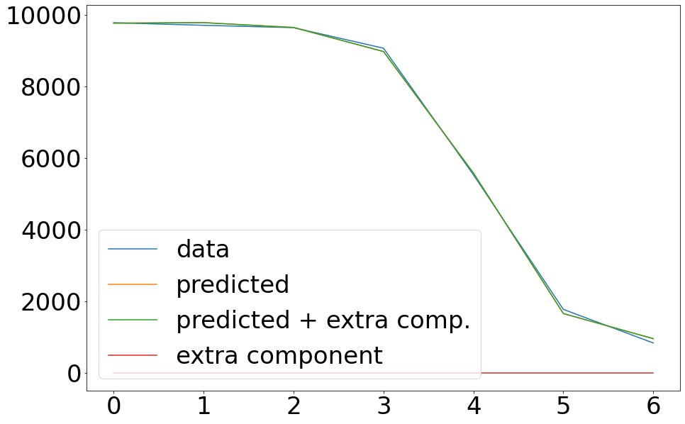

```python
pred = X_full.dot(soln)
plt.plot(y, label="data")
plt.plot(pred, label="predicted")
plt.plot(pred+eta, label="predicted + extra comp.")
plt.plot(eta, label="extra component")
plt.legend()
```

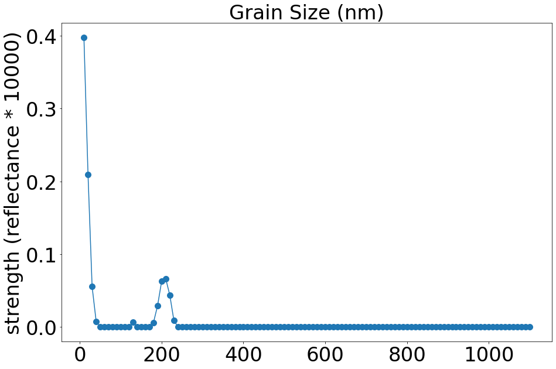

```python
plt.plot(grainsizes, soln[:-1], '.-', markersize=20)
plt.ylabel('strength (reflectance * 10000)')
plt.title('Grain Size (nm)')

#plt.savefig("Distribution.png", dpi=500, format="png", transparent=True)
```

### 4.2. Running the model for single grian size components

We can also fit each individual grain size and see which one leads to a smaller loss function. This is identified as the most likely grain size for a given MODIS image

```python
%%time

res = {}
constraint = "simplex"

for tm in all_times:

    # We fit the model to different pixels at the same time
    y = dsT.spectra[tm, 0:n_bands, :, :].values.flatten("F")

    Error = []
    gs_proportion = []

    def build_X(gs, X0=X0, nbands=7, rep=1):

        X = X0[:,gs].reshape(X0.shape[0],1)
        X = np.hstack((X, np.atleast_2d(spec_shadow).T))
        X = np.hstack((X, np.atleast_2d(X0[:,0]).T))
        # Just the first n_bands
        X = X[0:n_bands, :]
        Xr = np.tile(X, (rep,1))
        return Xr

    for gs in range(len(grainsizes)):

        Xr = build_X(gs, X0, n_bands, (xmax-xmin)*(ymax-ymin))

        soln, _, err = inverse_single_reflectance_huber_regreg(y, Xr, l1_penalties=nu_r, cons=constraint)

        Error.append(err)
        gs_proportion.append(soln[0])

    gs_min = np.argmin(Error)
    Xr = build_X(gs_min, X0, n_bands, (xmax-xmin)*(ymax-ymin))
    soln, _, err = inverse_single_reflectance_huber_regreg(y, Xr, l1_penalties=nu_r, cons=constraint)
    pred = Xr.dot(soln)

    res_tm = {"gs_min": gs_min,
              "Xr": Xr,
              "soln": soln,
              "Error": Error,
              "gs_proportion": gs_proportion,
              "pred": pred,
              "y": y}

    res[tm] = res_tm
```

```
CPU times: user 44min 16s, sys: 14.2 s, total: 44min 30s
Wall time: 44min 32s
```

```
(0.0, 1.0, 0.0, 1.0)
```

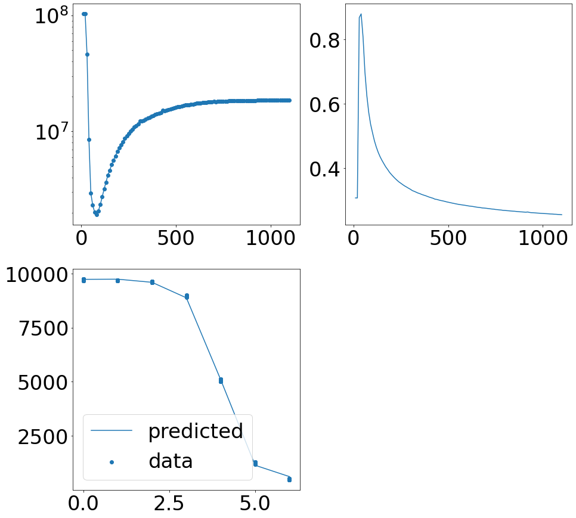

```python
gs = 197 # 102, 162, 136, 197

fig, ax = plt.subplots(2, 2, figsize=(15, 15))

ax[0,0].plot(grainsizes, res[gs]["Error"], "o-")
ax[0,0].set_yscale("log")
#ax[0,0].set_xscale("log")

ax[0,1].plot(grainsizes, res[gs]["gs_proportion"])

pred = res[gs]["Xr"].dot(res[gs]["soln"])

ax[1,0].scatter(np.tile(np.arange(n_bands), (xmax-xmin)*(ymax-ymin)), res[gs]["y"], label="data")
ax[1,0].plot(res[gs]["pred"][0:n_bands], label="predicted")
ax[1,0].legend()

ax[1,1].axis("off")
```

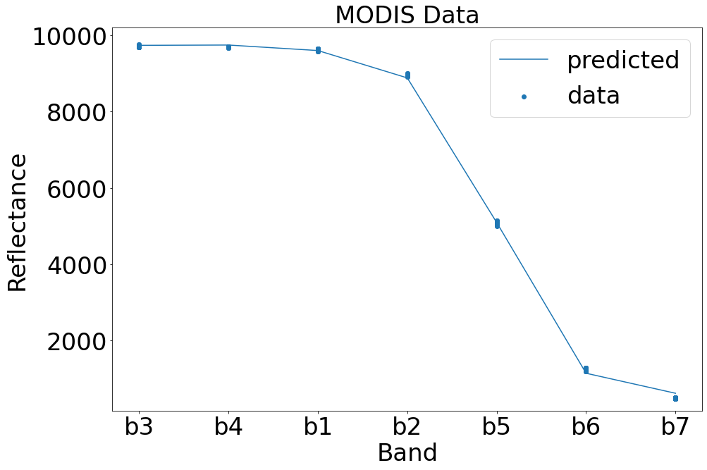

```python
plt.scatter(np.tile(np.arange(n_bands), (xmax-xmin)*(ymax-ymin)), res[gs]["y"], label="data")
plt.plot(data_x, res[gs]["pred"][0:n_bands], label="predicted")
plt.title("MODIS Data")
plt.xlabel("Band")
plt.ylabel("Reflectance");
plt.legend()

plt.savefig("Fit.png", dpi=300, format="png", transparent=True)
```

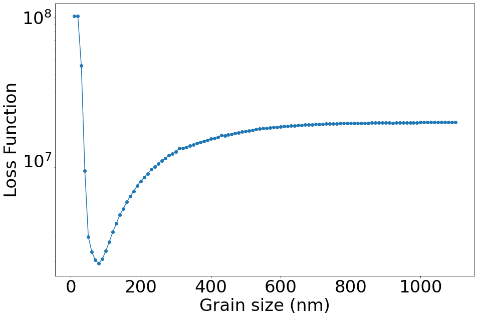

```python
plt.plot(grainsizes, res[gs]["Error"], "o-")
#plt.set_yscale("log")
plt.yscale("log")
plt.xlabel("Grain size (nm)")
plt.ylabel("Loss Function");

plt.savefig("Loss.png", dpi=300, format="png", transparent=True)
```

```python
GS = pd.DataFrame(columns=["idx_time", "mode", "weight", "error", "smooth", "shadow", "dust"])

make_plot = False
n_min = 5

#all_tm = np.linspace(0, dsT.sizes["time"]-1, 10, dtype=int)
all_tm = range(dsT.sizes["time"])

for tm in all_tm:

    Error_mean = np.mean(res[tm]["Error"])
    Error_std  = np.std(res[tm]["Error"])

    if Error_std == 0.0:
        continue

    Error_norm = (res[tm]["Error"] - Error_mean) / Error_std

    Error_smooth = np.linalg.norm(np.diff(Error_norm)).round(1) ** 2

    argmins = np.argsort(res[tm]["Error"])[0:n_min]
    gs_mins = np.take(grainsizes, argmins)
    gs_min = np.median(gs_mins)
    Err_mins = np.take(res[tm]["Error"], argmins)

    gs_summary = pd.DataFrame.from_dict({"idx_time": [tm],
                                         "mode": [gs_min],
                                         "weight": [res[tm]["gs_proportion"][argmins[0]]],
                                         "error": [np.min(Err_mins)],
                                         "smooth": [Error_smooth],
                                         "shadow": res[tm]["soln"][1],
                                         "dust": res[tm]["soln"][2]})

    GS = pd.concat([GS, gs_summary])
```

We appply some filters based on the value of the loss function and the smoothness of the minimum of loss function

```python
GS["time"] = GS.apply(lambda row : dsT.time.values[row.idx_time], axis=1)
GS = GS[GS.smooth < 100]
#GS = GS[(10 < GS.smooth) & (GS.smooth < 100)]
GS = GS[GS.error < 10**(7)]
GS = GS[GS.weight > 0.1]
GS
```

|  | idx_time | mode | weight | error | smooth | shadow | dust | time |
| --- | --- | --- | --- | --- | --- | --- | --- | --- |
| 0 | 8 | 320.0 | 0.190904 | 2.101684e+06 | 38.44 | 0.111875 | 0.697221 | 2011-05-02 15:00:00 |
| 0 | 13 | 110.0 | 0.327730 | 2.651820e+06 | 44.89 | 0.110333 | 0.561936 | 2011-05-03 14:05:00 |
| 0 | 14 | 230.0 | 0.204524 | 9.746626e+06 | 42.25 | 0.145478 | 0.649998 | 2011-05-03 15:45:00 |
| 0 | 19 | 60.0 | 0.347188 | 2.870829e+06 | 56.25 | 0.107975 | 0.544837 | 2011-05-04 13:10:00 |
| 0 | 20 | 100.0 | 0.454793 | 2.357337e+06 | 32.49 | 0.113161 | 0.432046 | 2011-05-04 14:50:00 |
| ... | ... | ... | ... | ... | ... | ... | ... | ... |
| 0 | 296 | 90.0 | 0.513435 | 2.089008e+06 | 31.36 | 0.099853 | 0.386712 | 2011-06-20 15:45:00 |
| 0 | 297 | 50.0 | 0.539063 | 3.560600e+06 | 60.84 | 0.098205 | 0.362733 | 2011-06-20 17:20:00 |
| 0 | 298 | 50.0 | 0.663825 | 3.509824e+06 | 62.41 | 0.089721 | 0.246454 | 2011-06-20 20:35:00 |
| 0 | 299 | 90.0 | 0.368824 | 4.281096e+06 | 40.96 | 0.148807 | 0.482369 | 2011-06-20 22:15:00 |
| 0 | 300 | 150.0 | 0.343480 | 6.090486e+06 | 26.01 | 0.255036 | 0.401484 | 2011-06-20 23:50:00 |

119 rows × 8 columns

Now, we just pick images close to the noon. In this way, we avoid dimmed images.

```python
GS = GS[(GS.time.dt.hour>11) & (GS.time.dt.hour<20)]
```

Now, we add the mask from the Summit station to the dataset

```python
def detection_status(my_time, Sd = Summit_data):

    Sd_sum = Sd[abs((my_time-Sd.date)/np.timedelta64(1, 's')) < 60]    # 600 --> 60

    if Sd_sum.shape[0] == 0:
        return NaN

    return Sd_sum.detection_status.mode()[0]
```

```python
GS["Summit_detection_status"] = GS.apply(lambda row: detection_status(row.time), axis=1)

GS = GS[GS.Summit_detection_status == "Clr"]
GS.shape
```

```
(53, 9)
```

```python
Times = GS["time"]
Climate = GS["Summit_detection_status"]
```

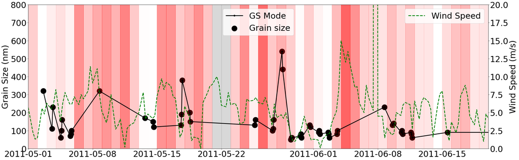

```python
fig, ax1 = plt.subplots(figsize=(30,10))
ax1.plot(GS["time"], GS["mode"], 'o-', color="black", lw=3, label="GS Mode")  # , ms=15,
ax1.scatter(GS["time"], GS["mode"], s=500, color="black", label="Grain size")
ax1.set_xlim(pd.to_datetime("2011-05-01"), pd.to_datetime("2011-06-20"))
ax1.set_ylim(0,800)
ax1.set_ylabel("Grain Size (nm)")
plt.legend()

initial_date = pd.to_datetime("2011-05-01")
final_date = pd.to_datetime("2011-06-30")

while initial_date < final_date:

    df = Summit_data[(Summit_data.date >= initial_date) & (Summit_data.date < initial_date + pd.Timedelta(1, unit="day"))]
    if df.shape[0] > 0:
        #clr = np.sum(df.detection_status=="Clr")/df.shape[0]
        obs = np.sum(df.detection_status=="Obscured")/df.shape[0]
        #ax1.axvspan(initial_date, initial_date+pd.Timedelta(1, unit="day"), alpha=0.5*clr, color="blue")
        ax1.axvspan(initial_date, initial_date+pd.Timedelta(1, unit="day"), alpha=obs, color="red")
    else:
        ax1.axvspan(initial_date, initial_date+pd.Timedelta(1, unit="day"), alpha=.3, color="gray")
    initial_date += pd.Timedelta(1, unit="day")

ax2 = ax1.twinx()
ax2.plot(Summit_weather.time, Summit_weather.Wind_Speed, "--", color="green", label="Wind Speed", lw=3)
ax2.set_ylim(0,20)
ax2.set_ylabel("Wind Speed (m/s)")


fig.tight_layout()
plt.legend()
#plt.show()

plt.savefig("Timeseries.png", dpi=500, format="png", transparent=True)
```